# ExtraaLearn Project

## Context

The EdTech industry has been surging in the past decade immensely, and according to a forecast, the Online Education market would be worth $286.62bn by 2023 with a compound annual growth rate (CAGR) of 10.26% from 2018 to 2023. The modern era of online education has enforced a lot in its growth and expansion beyond any limit. Due to having many dominant features like ease of information sharing, personalized learning experience, transparency of assessment, etc, it is now preferable to traditional education.

In the present scenario due to the Covid-19, the online education sector has witnessed rapid growth and is attracting a lot of new customers. Due to this rapid growth, many new companies have emerged in this industry. With the availability and ease of use of digital marketing resources, companies can reach out to a wider audience with their offerings. The customers who show interest in these offerings are termed as leads. There are various sources of obtaining leads for Edtech companies, like

- The customer interacts with the marketing front on social media or other online platforms.
- The customer browses the website/app and downloads the brochure
- The customer connects through emails for more information.

The company then nurtures these leads and tries to convert them to paid customers. For this, the representative from the organization connects with the lead on call or through email to share further details.

## Objective

ExtraaLearn is an initial stage startup that offers programs on cutting-edge technologies to students and professionals to help them upskill/reskill. With a large number of leads being generated regularly, one of the issues faced by ExtraaLearn is to identify which of the leads are more likely to convert so that they can allocate resources accordingly. You, as a data scientist at ExtraaLearn, have been provided the leads data to:

- Analyze and build an ML model to help identify which leads are more likely to convert to paid customers,
- Find the factors driving the lead conversion process
- Create a profile of the leads which are likely to convert

## Data Description

The data contains the different attributes of leads and their interaction details with ExtraaLearn. The detailed data dictionary is given below.

**Data Dictionary**

- ID: ID of the lead
- age: Age of the lead
- current_occupation: Current occupation of the lead. Values include 'Professional','Unemployed',and 'Student'
- first_interaction: How did the lead first interact with ExtraaLearn. Values include 'Website', 'Mobile App'
- profile_completed: What percentage of the profile has been filled by the lead on the website/mobile app. Values include Low - (0-50%), Medium - (50-75%), High (75-100%)
- website_visits: How many times has a lead visited the website
- time_spent_on_website: Total time spent on the website
- page_views_per_visit: Average number of pages on the website viewed during the visits.
- last_activity: Last interaction between the lead and ExtraaLearn.
  - Email Activity: Seeking for details about the program through email, Representative shared information with a lead like a brochure of program, etc
  - Phone Activity: Had a Phone Conversation with a representative, Had conversation over SMS with a representative, etc
  - Website Activity: Interacted on live chat with a representative, Updated profile on the website, etc
- print_media_type1: Flag indicating whether the lead had seen the ad of ExtraaLearn in the Newspaper.
- print_media_type2: Flag indicating whether the lead had seen the ad of ExtraaLearn in the Magazine.
- digital_media: Flag indicating whether the lead had seen the ad of ExtraaLearn on the digital platforms.
- educational_channels: Flag indicating whether the lead had heard about ExtraaLearn in the education channels like online forums, discussion threads, educational websites, etc.
- referral: Flag indicating whether the lead had heard about ExtraaLearn through reference.
- status: Flag indicating whether the lead was converted to a paid customer or not.

## **Importing necessary libraries**

```python
import warnings

warnings.filterwarnings("ignore")
from statsmodels.tools.sm_exceptions import ConvergenceWarning

warnings.simplefilter("ignore", ConvergenceWarning)

# Libraries to help with reading and manipulating data

import pandas as pd
import numpy as np

# Library to split data
from sklearn.model_selection import train_test_split

# libaries to help with data visualization
import matplotlib.pyplot as plt
import seaborn as sns

# Removes the limit for the number of displayed columns
pd.set_option("display.max_columns", None)
# Sets the limit for the number of displayed rows
pd.set_option("display.max_rows", 200)
# setting the precision of floating numbers to 5 decimal points
pd.set_option("display.float_format", lambda x: "%.5f" % x)

# To build model for prediction
import statsmodels.stats.api as sms
from statsmodels.stats.outliers_influence import variance_inflation_factor
import statsmodels.api as sm
from statsmodels.tools.tools import add_constant
from sklearn.linear_model import LogisticRegression
from sklearn.tree import DecisionTreeClassifier
from sklearn import tree
from sklearn.ensemble import RandomForestClassifier

# To tune different models
from sklearn.model_selection import GridSearchCV


# To get different metric scores
import sklearn.metrics as metrics
from sklearn.metrics import (
    f1_score,
    accuracy_score,
    recall_score,
    precision_score,
    confusion_matrix,
    classification_report,
    roc_auc_score,
    precision_recall_curve,
    roc_curve,
    make_scorer,
)

from sklearn.utils.class_weight import compute_class_weight
from sklearn.model_selection import learning_curve
```

## **Import Dataset**

```python
learn = pd.read_csv("ExtraaLearn.csv")
```

```python
# copying data to another variable to avoid any changes to original data
data = learn.copy()
```

#### View the first and last 5 rows of the dataset

```python
data.head()
```

|  | ID | age | current_occupation | first_interaction | profile_completed | website_visits | time_spent_on_website | page_views_per_visit | last_activity | print_media_type1 | print_media_type2 | digital_media | educational_channels | referral | status |
| --- | --- | --- | --- | --- | --- | --- | --- | --- | --- | --- | --- | --- | --- | --- | --- |
| 0 | EXT001 | 57 | Unemployed | Website | High | 7 | 1639 | 1.86100 | Website Activity | Yes | No | Yes | No | No | 1 |
| 1 | EXT002 | 56 | Professional | Mobile App | Medium | 2 | 83 | 0.32000 | Website Activity | No | No | No | Yes | No | 0 |
| 2 | EXT003 | 52 | Professional | Website | Medium | 3 | 330 | 0.07400 | Website Activity | No | No | Yes | No | No | 0 |
| 3 | EXT004 | 53 | Unemployed | Website | High | 4 | 464 | 2.05700 | Website Activity | No | No | No | No | No | 1 |
| 4 | EXT005 | 23 | Student | Website | High | 4 | 600 | 16.91400 | Email Activity | No | No | No | No | No | 0 |

```python
data.tail()
```

|  | ID | age | current_occupation | first_interaction | profile_completed | website_visits | time_spent_on_website | page_views_per_visit | last_activity | print_media_type1 | print_media_type2 | digital_media | educational_channels | referral | status |
| --- | --- | --- | --- | --- | --- | --- | --- | --- | --- | --- | --- | --- | --- | --- | --- |
| 4607 | EXT4608 | 35 | Unemployed | Mobile App | Medium | 15 | 360 | 2.17000 | Phone Activity | No | No | No | Yes | No | 0 |
| 4608 | EXT4609 | 55 | Professional | Mobile App | Medium | 8 | 2327 | 5.39300 | Email Activity | No | No | No | No | No | 0 |
| 4609 | EXT4610 | 58 | Professional | Website | High | 2 | 212 | 2.69200 | Email Activity | No | No | No | No | No | 1 |
| 4610 | EXT4611 | 57 | Professional | Mobile App | Medium | 1 | 154 | 3.87900 | Website Activity | Yes | No | No | No | No | 0 |
| 4611 | EXT4612 | 55 | Professional | Website | Medium | 4 | 2290 | 2.07500 | Phone Activity | No | No | No | No | No | 0 |

#### Understand the shape of the dataset

```python
data.shape
```

```
(4612, 15)
```

```python
# checking for duplicate values
data["ID"].nunique()
```

```
4612
```

```python
# checking for duplicate values
data.duplicated().sum()
```

```
np.int64(0)
```

##### Observations:

- The dataset has no duplicated record.

#### Check the data types of the columns for the dataset

```python
data.dtypes
```

```
ID                        object
age                        int64
current_occupation        object
first_interaction         object
profile_completed         object
website_visits             int64
time_spent_on_website      int64
page_views_per_visit     float64
last_activity             object
print_media_type1         object
print_media_type2         object
digital_media             object
educational_channels      object
referral                  object
status                     int64
dtype: object
```

## **Exploratory Data Analysis**

**Statistical summary of the data.**

```python
data.describe().T
```

|  | count | mean | std | min | 25% | 50% | 75% | max |
| --- | --- | --- | --- | --- | --- | --- | --- | --- |
| age | 4612.00000 | 46.20121 | 13.16145 | 18.00000 | 36.00000 | 51.00000 | 57.00000 | 63.00000 |
| website_visits | 4612.00000 | 3.56678 | 2.82913 | 0.00000 | 2.00000 | 3.00000 | 5.00000 | 30.00000 |
| time_spent_on_website | 4612.00000 | 724.01127 | 743.82868 | 0.00000 | 148.75000 | 376.00000 | 1336.75000 | 2537.00000 |
| page_views_per_visit | 4612.00000 | 3.02613 | 1.96812 | 0.00000 | 2.07775 | 2.79200 | 3.75625 | 18.43400 |
| status | 4612.00000 | 0.29857 | 0.45768 | 0.00000 | 0.00000 | 0.00000 | 1.00000 | 1.00000 |

**List of count of each unique value in each column**

```python
# Making a list of all catrgorical variables except ID
cat_col = list(data.drop(["ID"], axis = 1).select_dtypes("object").columns)

# Printing number of count of each unique value in each column
for column in cat_col:
    print(data[column].value_counts())
    print("-" * 50)
```

```
current_occupation
Professional    2616
Unemployed      1441
Student          555
Name: count, dtype: int64
--------------------------------------------------
first_interaction
Website       2542
Mobile App    2070
Name: count, dtype: int64
--------------------------------------------------
profile_completed
High      2264
Medium    2241
Low        107
Name: count, dtype: int64
--------------------------------------------------
last_activity
Email Activity      2278
Phone Activity      1234
Website Activity    1100
Name: count, dtype: int64
--------------------------------------------------
print_media_type1
No     4115
Yes     497
Name: count, dtype: int64
--------------------------------------------------
print_media_type2
No     4379
Yes     233
Name: count, dtype: int64
--------------------------------------------------
digital_media
No     4085
Yes     527
Name: count, dtype: int64
--------------------------------------------------
educational_channels
No     3907
Yes     705
Name: count, dtype: int64
--------------------------------------------------
referral
No     4519
Yes      93
Name: count, dtype: int64
--------------------------------------------------
```

## **Univariate Analysis on Numerical Features**

Boxplot will be used to visualize the distribution and histogram displays the frequency distribution of the dataset.

```python
#Remark: the following codes are reutilized from Low Code Version - Potential Customers Prediction.
# Modication: Show boxplot and histogram alongside in a row
# function to plot a boxplot and a histogram along the same scale.
def histogram_boxplot(data, feature, figsize=(20, 3.5), kde=False, bins=None):
    """
    Boxplot and histogram combined
    data: dataframe
    feature: dataframe column
    figsize: size of figure (default (20,3.5))
    kde: whether to the show density curve (default False)
    bins: number of bins for histogram (default None)
    """
    f2, (ax_box2, ax_hist2) = plt.subplots(
        ncols=2,  # Number of columns of the subplot grid = 2
        gridspec_kw={
            "width_ratios": (0.45, 0.55),  # increased boxplot width ratio
            "wspace": 0.2  # reduced spacing between plots
        },
        figsize=figsize,
    )  # creating the 2 subplots

    sns.boxplot(
        data=data, x=feature, ax=ax_box2, showmeans=True, color="violet"
    )  # boxplot will be created and a star will indicate the mean value of the column

    sns.histplot(
        data=data, x=feature, kde=kde, ax=ax_hist2, bins=bins, palette="winter"
    ) if bins else sns.histplot(
        data=data, x=feature, kde=kde, ax=ax_hist2
    )

    # For histogram
    ax_hist2.axvline(data[feature].mean(), color="green", linestyle="--")  # Add mean to the histogram
    ax_hist2.axvline(data[feature].median(), color="black", linestyle="-")  # Add median to the histogram
```

#### Distribution on age

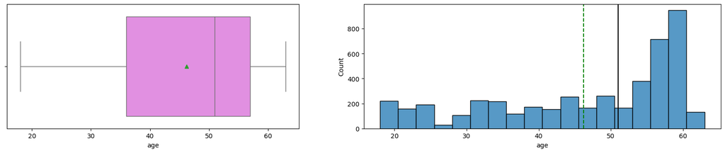

```python
histogram_boxplot(data, "age")
```

**Observations:**

###### Boxplot:

- 50% leads (IQR) have a age range of roughly between 35-58.
- No significant outliers are found.

###### Histyogram:

- The highest concentration of ages range is 50-60.
- There's a lower density of ages in the range 25-30.
- There's a moderate concentration in the range 30-50.

#### Distribution on website_visits

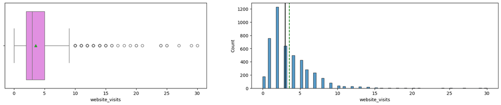

```python
histogram_boxplot(data, "website_visits")
```

**Observations:**

##### Boxplot:

- The IQR is narrow, approximately between 2-5 visits.
- There are many outliers extending from 10 to 30 visits.

##### Histyogram:

- The majority of leads have 0-5 website visits, with a mean aropund 4.
- Website vists drop significantly after 5 times.

#### Distribution on time_spent_on_website

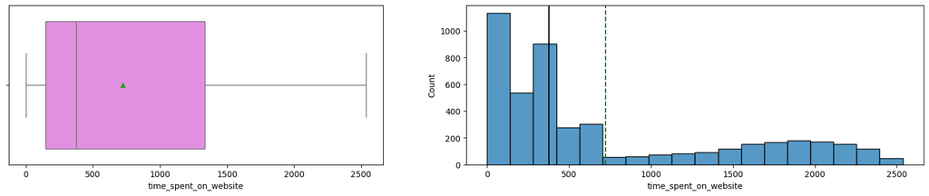

```python
histogram_boxplot(data, "time_spent_on_website")
```

**Observations:**

##### Histogram:

- The distribution is right-skewed, with most users spending time in the range 0 - 600, with some users spending more time (1500-2500).
- High concentration of leads have time spent on website in the lower time ranges (0-500 minutes).

#### Distribution on page_views_per_visit

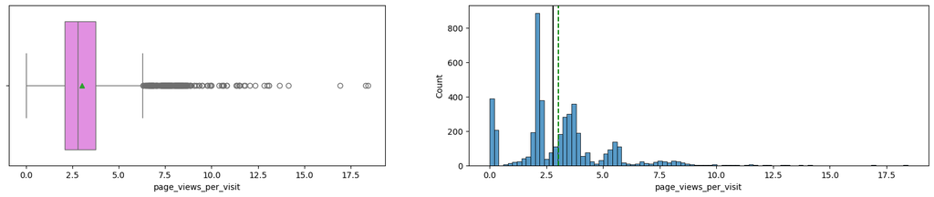

```python
histogram_boxplot(data, "page_views_per_visit")
```

**Observations:**

##### Histogram:

- The distribution is right-skewed, with most users having between 1.5-5.5 page views per visit.
- Page views drop sharply after about 6 pages view

## **Univariate Analysis on Categorical Features**

```python
#Remark: the following codes are reutilized from Low Code Version - Potential Customers Prediction.
# function to create labeled barplots
def labeled_barplot(data, feature, perc=False, n=None):
    """
    Barplot with percentage at the top

    Parameters:
    -----------
    data: dataframe
        Input dataframe
    feature: str
        Dataframe column to plot
    perc: bool, default False
        Whether to display percentages instead of count
    n: int, optional
        Displays the top n category levels (default is None, i.e., display all levels)
    """
    total = len(data[feature])  # length of the column
    count = data[feature].nunique()
    if n is None:
        # Reduce figure size by 40%
        plt.figure(figsize=((count + 1) * 0.9, 4))
    else:
        plt.figure(figsize=((n + 1) * 0.9, 4))

    # Adjust font sizes
    plt.xticks(rotation=45, fontsize=9)
    plt.yticks(fontsize=9)

    ax = sns.countplot(
        data=data,
        x=feature,
        palette="Paired",
        order=data[feature].value_counts().index[:n].sort_values(),
    )

    # Adjust title and label font sizes
    ax.set_xlabel(feature, fontsize=10)
    ax.set_ylabel("count", fontsize=10)

    # Set new y-axis limits with buffer space at the top
    y_min, y_max = ax.get_ylim()
    buffer = 0.05 * y_max
    ax.set_ylim(y_min, y_max + buffer)

    for p in ax.patches:
        if perc:
            label = "{:.1f}%".format(
                100 * p.get_height() / total
            )  # percentage of each class of the category
        else:
            label = p.get_height()  # count of each level of the category

        x = p.get_width() / 2 + p.get_x()  # width of the plot
        y = p.get_height()  # height of the plot

        ax.annotate(
            label,
            (x, y),
            ha="center",
            va="center",
            size=9,  # Reduced annotation font size
            xytext=(0, 6),  # Reduced offset
            textcoords="offset points"
        )  # annotate the percentage

    plt.tight_layout()  # Ensure plot fits in the figure
    plt.show()  # show the plot
```

#### Distribution on current_occupation

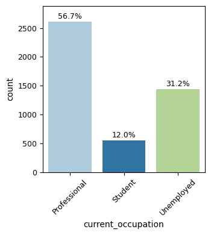

```python
labeled_barplot(data, "current_occupation", perc=True)
```

**Observations:**

- Over half (56.7%) of leads are professional, followed by unemployed (31.2%) and only small portion (12%) of them are students.
- Professional leads are more afforable to pay for online education.
- Unemployed leads are more encouraged to have online education because of better job market opportunities.
- Low percentages of students because students generally are not affordable for online education.

### Distribution on first_interaction

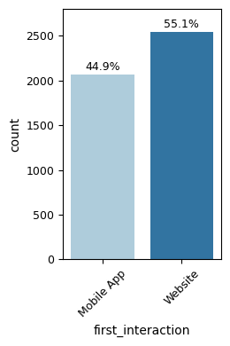

```python
labeled_barplot(data, "first_interaction", perc=True)
```

**Observations:**

- Both mobile app and website are important channels for leads engagements.
- Website is the primary first interaction point and mobile app is also strong.
- This means the they should be maintained for consistent user experiences because they're main entry points for users.

#### Distribution on profile_completed

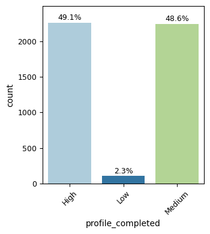

```python
labeled_barplot(data, "profile_completed", perc=True)
```

**Observations:**

- High and medium completetion levels are almost equally high, and very proportion of leads have low profile completion. The profile completion rate is overall very well.
- The overall profile completion rate is well enough and only very fewleadss leave their profiles in ExtraaLearn empty.
- High profile completion rates mean opportunities to utilize the profile data for personalized user experiences.
- There is a need to investigate into any barries fleadsers of low profile completion rates.
- More should be done to convert medium completion profiles ito ..high

#### Observations on last_activity

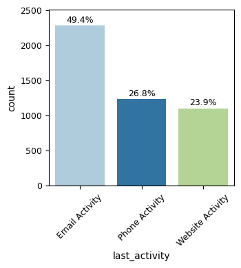

```python
labeled_barplot(data, "last_activity", perc=True)
```

**Observations:**

- Email activiy is most important final touch point in leads engagement, followed by phone and website.
- High percentage of email activity means the email marketing is effective.
- Substantial phone activity indicates importance of personal contact.
- Also, substantial website activity means importance of online information for users.
- As the website activty is lowest, website engagement should be improved because this could encourage real courses enrollment.

#### Distribution on print_media_type1 (Newspaper Advertisements)

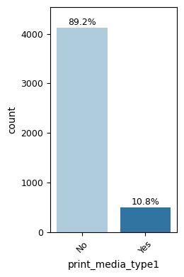

```python
labeled_barplot(data, "print_media_type1", perc=True)
```

**Observations:**

- Only 10.8% leads reached through this media channel.
- Obviously this channel is not effective for leads engagement.
- As importance of paper media is declining in modern world, the management should review the resources allocation pent on newspaper advertistments for better conversion effectiveness.

#### Distribution on print_media_type2 (Magazine Advertisements)

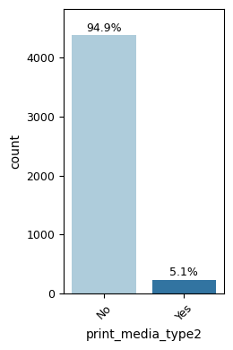

```python
labeled_barplot(data, "print_media_type2", perc=True)
```

**Observations:**

- Similar to newspapers.

#### Distribution on digital_media

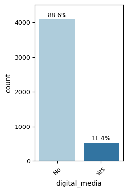

```python
labeled_barplot(data, "digital_media", perc=True)
```

**Observations:**

- The pattern is almost the same as newspapers and magazines.
- Assume digital media means social media such as facebook, instragram, twitter, youtube or online advertisments, and lead engagements mean that leads access ExtraaLearn information. The above plot shows that leads engagement with digital media is very low.
- Unlike newspaper and magzine channels, the effectiveness of digital media should be reviewed and improved because digital media is a main trend in modern marketing.

#### Distribution on educational_channels

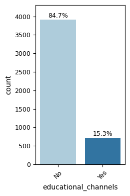

```python
labeled_barplot(data, "educational_channels", perc=True)
```

**Observations:**

- The pattern is almost the same as digital media.
- The effectiveness of educational channels should be reviewed and improved.

#### Distribution on referral

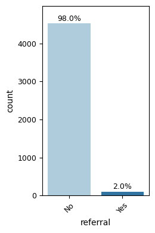

```python
labeled_barplot(data, "referral", perc=True)
```

**Observations:**

- Only 2% leads heard about ExtraaLearn means its popularity should be improved.
- More resources (e.g, referral fee or discount) should be used to promote referral as words of mouth is a effective way to attract potential customers.

#### Distribution on status

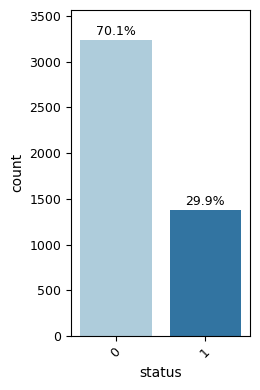

```python
labeled_barplot(data, "status", perc=True)
```

**Observations:**

- Only about 30% of leads are converted into paying customers, indicating significant potential for improvement.
- Unconverted leads make up 70%, suggesting that the current marketing resources and strategies are not effective enough.

## **Bivariate Analysis**

A heat map is used to check multicollinearity among variables.

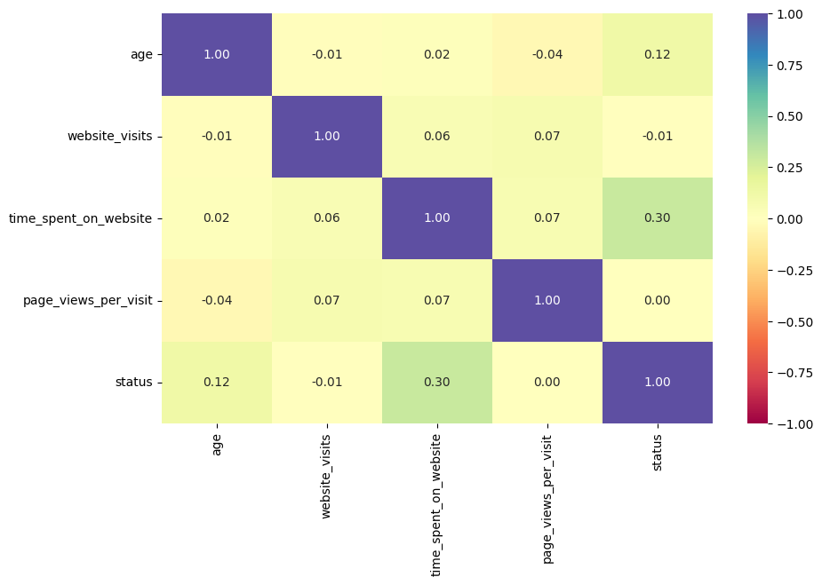

```python
cols_list = data.select_dtypes(include=np.number).columns.tolist()

plt.figure(figsize=(10, 6))
sns.heatmap(
    data[cols_list].corr(), annot=True, vmin=-1, vmax=1, fmt=".2f", cmap="Spectral"
)
plt.show()
```

**Observations:**

#### Analysis of relationships between Features and Target

In order to find out how the features affect the status, we use stacked barpot and distribution plot to visualize the relationship between a categorical variable and the target variable (status). Staked barplot shows the proportion of features in different target classes (converted/not converted), and distribution plot shows how different features distribute across different target classes. This can help identify which groups are more likely to convert.

In this case, the codes for stacked barplot and distribution plot are reutilized from Low Code Version - Potential Customers Prediction. There are slight modifications to original codes:

1. Adjust the plot size for better readability
2. Add percentage figures to stacked barplot
3. Add green line (mean) and black line (median) to distribution plot

```python
### function to plot distributions wrt target
def distribution_plot_wrt_target(data, predictor, target):
    fig, axs = plt.subplots(2, 2, figsize=(10, 7))
    target_uniq = data[target].unique()

    # histogram with kde for target = target_uniq[0]
    axs[0, 0].set_title("Distribution of target for target=" + str(target_uniq[0]))
    sns.histplot(
        data=data[data[target] == target_uniq[0]],
        x=predictor,
        kde=True,
        ax=axs[0, 0],
        color="teal",
        stat="density",
    )

    # Calculate mean and median
    mean_0 = data[data[target] == target_uniq[0]][predictor].mean()
    median_0 = data[data[target] == target_uniq[0]][predictor].median()

    # Add vertical lines for mean and median
    axs[0, 0].axvline(mean_0, color="green", linestyle="--", label='Mean')
    axs[0, 0].axvline(median_0, color="black", linestyle="-", label='Median')
    axs[0, 0].legend()

    # histogram with kde for target = target_uniq[1]
    axs[0, 1].set_title("Distribution of target for target=" + str(target_uniq[1]))
    sns.histplot(
        data=data[data[target] == target_uniq[1]],
        x=predictor,
        kde=True,
        ax=axs[0, 1],
        color="orange",
        stat="density",
    )

    # Calculate mean and median
    mean_1 = data[data[target] == target_uniq[1]][predictor].mean()
    median_1 = data[data[target] == target_uniq[1]][predictor].median()

    # Add vertical lines for mean and median
    axs[0, 1].axvline(mean_1, color="green", linestyle="--", label='Mean')
    axs[0, 1].axvline(median_1, color="black", linestyle="-", label='Median')
    axs[0, 1].legend()

    # box plot
    axs[1, 0].set_title("Boxplot w.r.t target")
    sns.boxplot(data=data, x=target, y=predictor, ax=axs[1, 0], palette="gist_rainbow")

    axs[1, 1].set_title("Boxplot (without outliers) w.r.t target")
    sns.boxplot(
        data=data,
        x=target,
        y=predictor,
        ax=axs[1, 1],
        showfliers=False,
        palette="gist_rainbow",
    )

    plt.tight_layout()
    plt.show()
```

```python
### function to stacked bar plot
def stacked_barplot(data, predictor, target):
    """
    Print the category counts and plot a stacked bar chart
    data: dataframe
    predictor: independent variable
    target: target variable
    """
    count = data[predictor].nunique()
    sorter = data[target].value_counts().index[-1]

    # Create a cross-tabulation of predictor and target
    tab1 = pd.crosstab(data[predictor], data[target], margins=True).sort_values(
        by=sorter, ascending=False
    )

    # Calculate and format the Conversion Rate as a percentage string
    tab1['Conversion Rate'] = (tab1[1] / tab1['All']) * 100  # Assuming '1' is the paid customer status
    tab1['Conversion Rate'] = tab1['Conversion Rate'].map('{:.2f}%'.format)

    # Bold the "Conversion Rate" column header
    tab1_styled = tab1.style.set_table_styles(
        {
            'Conversion Rate': [{'selector': 'th', 'props': [('font-weight', 'bold')]}],
            '': [{'selector': 'th', 'props': [('font-weight', 'normal')]}],  # Other headers normal
        }
    )

    # Display the styled DataFrame
    display(tab1_styled)
    print("-" * 120)

    # Create normalized cross-tabulation
    tab = pd.crosstab(data[predictor], data[target], normalize="index").sort_values(by=sorter, ascending=False)

    # Plot the stacked bar chart
    ax = tab.plot(kind="bar", stacked=True, figsize=((count + 5) * 0.6, 5 * 0.8))

    # Annotate bars with percentage values
    for p in ax.patches:
        height = p.get_height()
        if height > 0:  # Avoid division by zero
            ax.annotate(f'{height:.2%}',
                        (p.get_x() + p.get_width() / 2., p.get_y() + height - 0.05),
                        ha='center', va='bottom', fontsize=9, color='black')

    plt.xticks(rotation=45, fontsize=9)
    plt.yticks(fontsize=9)
    plt.legend(loc="lower left", frameon=False)
    plt.legend(loc="upper left", bbox_to_anchor=(1, 1))
    plt.show()
```

```python
# calculate the interquartile ranges and mean
def getIQR(data, feature):
    """
    Calculate the interquartile range (Q1, Q2, Q3) and mean for a specified feature, broken down by status.

    Parameters:
    - data: pd.DataFrame: The input DataFrame containing the data.
    - feature: str: The name of the feature for which to calculate the IQR and mean.

    Returns:
    - list of str: A list containing formatted strings with the feature, status, IQR, and mean.
    """
    results = []

    # Get unique statuses
    statuses = data['status'].unique()

    print(f"Feature: {feature}")
    for status in statuses:
        # Filter the data based on the current status
        filtered_data = data[data['status'] == status][feature]

        # Calculate Q1, Q2 (median), and Q3
        Q1 = filtered_data.quantile(0.25)
        Q2 = filtered_data.median()  # Median is Q2
        Q3 = filtered_data.quantile(0.75)

        # Calculate mean
        mean_value = filtered_data.mean()

        # Format the result with two decimal places
        print('')
        print(f"Status: {status}")
        print(f"IQR: (Q1: {Q1:.2f}, Q2: {Q2:.2f}, Q3: {Q3:.2f})")
        print(f"Mean: {mean_value:.2f}")
```

#### Proportion of Conversions by Current Occupation

| status current_occupation | 0 | 1 | All | Conversion Rate |
| --- | --- | --- | --- | --- |
| All | 3235 | 1377 | 4612 | 29.86% |
| Professional | 1687 | 929 | 2616 | 35.51% |
| Unemployed | 1058 | 383 | 1441 | 26.58% |
| Student | 490 | 65 | 555 | 11.71% |

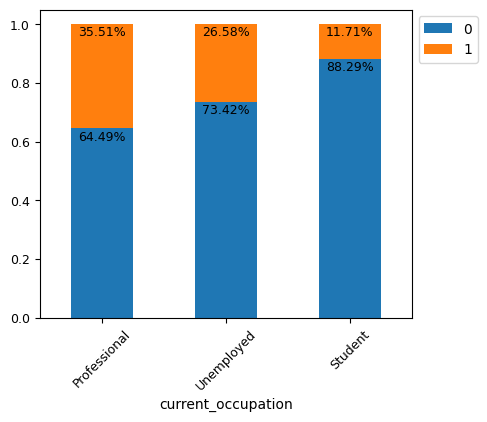

```python
stacked_barplot(data, "current_occupation", "status")
```

**Observations:**

- Professional has highest conversion rate, followed by unemployed and student.

#### Age Distribution by Current Occupation

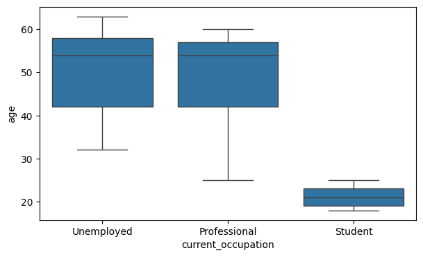

```python
plt.figure(figsize=(7, 4))
sns.boxplot(data = data, x = data["current_occupation"], y = data["age"])
plt.show()
```

```python
data.groupby(["current_occupation"])["age"].describe()
```

| current_occupation | count | mean | std | min | 25% | 50% | 75% | max |
| --- | --- | --- | --- | --- | --- | --- | --- | --- |
| Professional | 2616.00000 | 49.34748 | 9.89074 | 25.00000 | 42.00000 | 54.00000 | 57.00000 | 60.00000 |
| Student | 555.00000 | 21.14414 | 2.00111 | 18.00000 | 19.00000 | 21.00000 | 23.00000 | 25.00000 |
| Unemployed | 1441.00000 | 50.14018 | 9.99950 | 32.00000 | 42.00000 | 54.00000 | 58.00000 | 63.00000 |

**Observations:**

#### Proportion of Conversions by First Interaction

| status first_interaction | 0 | 1 | All | Conversion Rate |
| --- | --- | --- | --- | --- |
| All | 3235 | 1377 | 4612 | 29.86% |
| Website | 1383 | 1159 | 2542 | 45.59% |
| Mobile App | 1852 | 218 | 2070 | 10.53% |

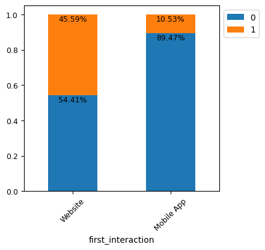

```python
stacked_barplot(data, "first_interaction", "status")
```

#### Observations:

- Website channel is much more effective in leads conversion than mobile app.

#### Analysis of Time Spent on Website by Conversion Status

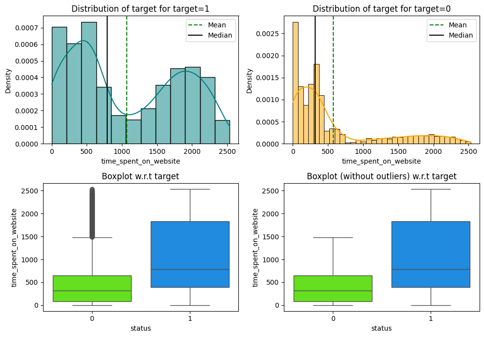

```python
distribution_plot_wrt_target(data, "time_spent_on_website", "status")
```

#### Interquartile Range of time_spent_on_website across different classes (status=0 or 1)

```python
getIQR(data, "time_spent_on_website")
```

```
Feature: time_spent_on_website

Status: 1
IQR: (Q1: 390.00, Q2: 789.00, Q3: 1829.00)
Mean: 1068.40

Status: 0
IQR: (Q1: 88.00, Q2: 317.00, Q3: 646.00)
Mean: 577.42
```

**Observations:**

##### Converted Case (target=1)

- The distribution plot shows a diversified distribution with peaks at around the 500 and 2000, indicating that these times are most common in converted group.
- Converted leads generally have 1068 average time spent on website.
- The boxplot shows a wider interquartile range (IQR) (390, 1829) compared to non-converted case, indicating greater variability in time in converted group.

##### Non-converted Case (target=0)

- The distribution plot shows that time spent on website is more concentrated at around lower values, indicating that non-converted users generally spent less time on the website.
- Non-converted group have a mean 577 time spent on website, which much lower than converted group.
- The boxplot shows that significant outliers are present in the non-converted group, indicating some users spent an exceptionally long time on the website but finally decide not to apply any course.

#### Analysis of Website Visits by Conversion Status

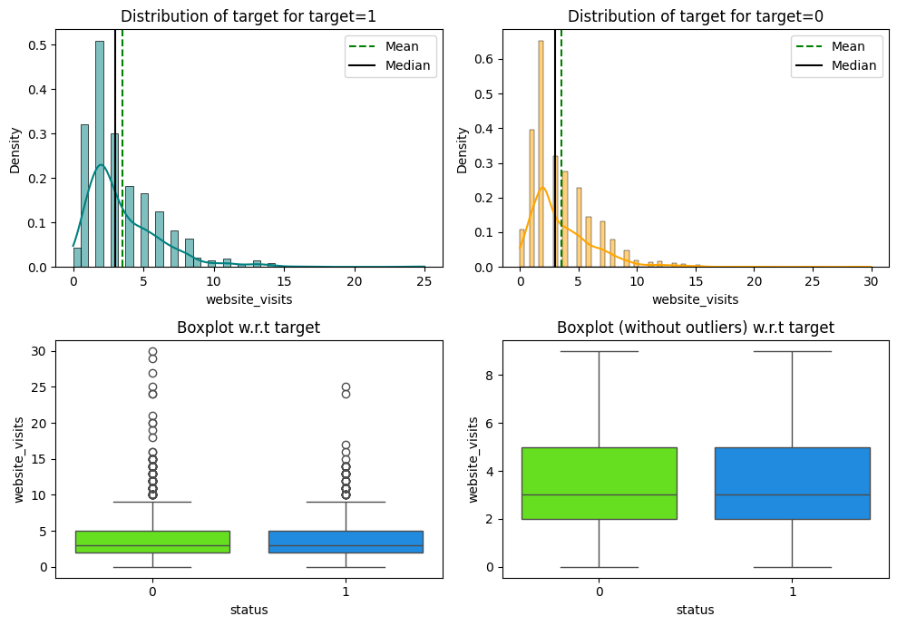

```python
distribution_plot_wrt_target(data, "website_visits", "status")
```

#### Interquartile Range

```python
getIQR(data, "website_visits")
```

```
Feature: website_visits

Status: 1
IQR: (Q1: 2.00, Q2: 3.00, Q3: 5.00)
Mean: 3.54

Status: 0
IQR: (Q1: 2.00, Q2: 3.00, Q3: 5.00)
Mean: 3.58
```

**Observations:**

##### Converted groups (target=1)

- The distribution plot is right-skewed with a mean 3.54 website visits. The website visit drops rapidly after 5 visits.
- Converted group have a IQR 2-5 and mean 3.54 website visits.
- Some converted leads have extra high website visits of 10 to over 15, and even 25.

##### Non-converted Case (target=0)

- The distribution plot shape is similar to converted group.
- Non-converted group have a similar IQR and mean to converted group.
- Some non-converted leads have extra high website vists ranging from 10 to 30. This is noticeable because it means those leads decide not to join any courses even they're so many website visits.

#### Analysis of Page Views Per Visit by Conversion Status

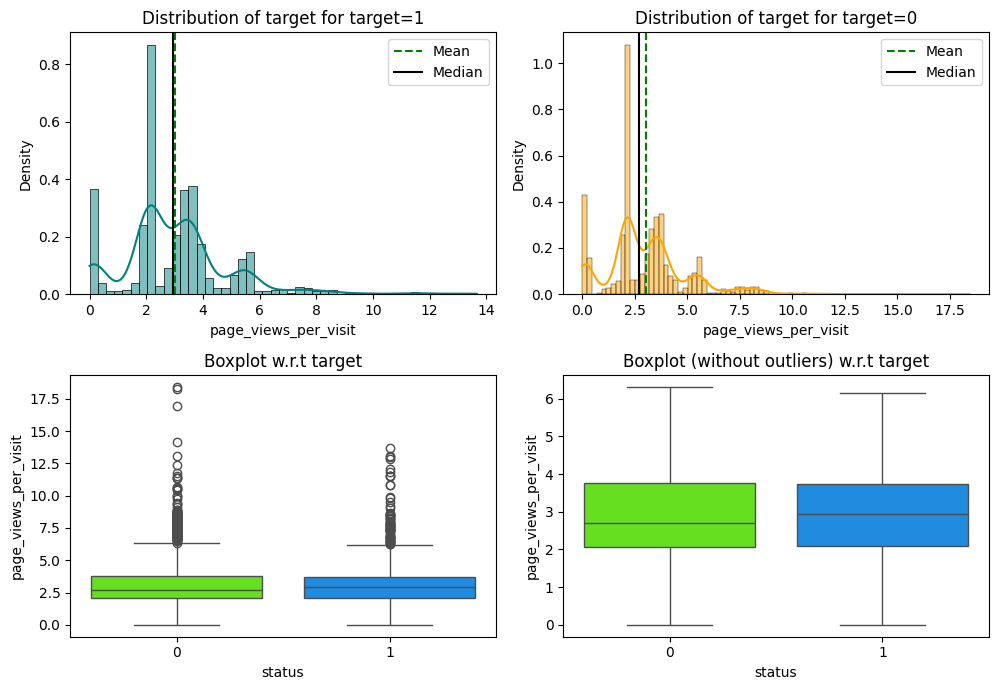

```python
distribution_plot_wrt_target(data, "page_views_per_visit", "status")
```

#### Interquartile Range

```python
getIQR(data, "page_views_per_visit")
```

```
Feature: page_views_per_visit

Status: 1
IQR: (Q1: 2.08, Q2: 2.94, Q3: 3.73)
Mean: 3.03

Status: 0
IQR: (Q1: 2.07, Q2: 2.71, Q3: 3.77)
Mean: 3.03
```

**Obseverations:**

#### Proportion of Conversions by Profile Completed

| status profile_completed | 0 | 1 | All | Conversion Rate |
| --- | --- | --- | --- | --- |
| All | 3235 | 1377 | 4612 | 29.86% |
| High | 1318 | 946 | 2264 | 41.78% |
| Medium | 1818 | 423 | 2241 | 18.88% |
| Low | 99 | 8 | 107 | 7.48% |

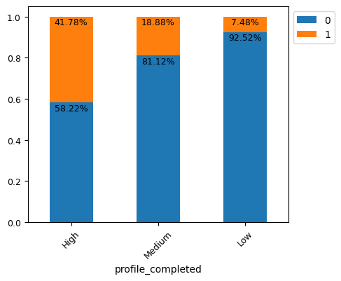

```python
stacked_barplot(data, "profile_completed", "status")
```

**Observations:**

#### Proportion of Conversions by Last Activity

| status last_activity | 0 | 1 | All | Conversion Rate |
| --- | --- | --- | --- | --- |
| All | 3235 | 1377 | 4612 | 29.86% |
| Email Activity | 1587 | 691 | 2278 | 30.33% |
| Website Activity | 677 | 423 | 1100 | 38.45% |
| Phone Activity | 971 | 263 | 1234 | 21.31% |

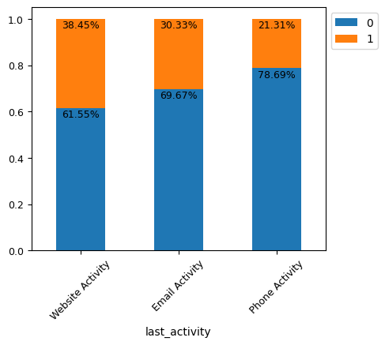

```python
stacked_barplot(data, "last_activity", "status")
```

**Observations:**

- Website activity or email activity have high conversion rate, followed by phone activity.

#### Proportion of Conversions by Print Media Type 1 (Newspaper Ad)

| status print_media_type1 | 0 | 1 | All | Conversion Rate |
| --- | --- | --- | --- | --- |
| All | 3235 | 1377 | 4612 | 29.86% |
| No | 2897 | 1218 | 4115 | 29.60% |
| Yes | 338 | 159 | 497 | 31.99% |

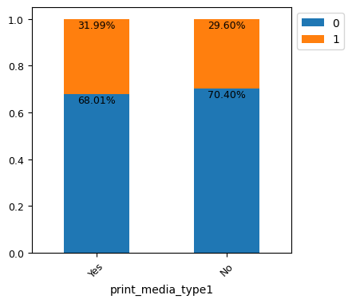

```python
stacked_barplot(data, "print_media_type1", "status")
```

**Observations:**

- The conversion rates are similar in both group (Yes/No).
- Combined with the fact that only 10% leads access newspaper ad, it can conclude that newspaper ad doesn't have clear effect on conversion rate.

#### Proportion of Conversions by Print Media Type 2 (Magazine Ad)

| status print_media_type2 | 0 | 1 | All | Conversion Rate |
| --- | --- | --- | --- | --- |
| All | 3235 | 1377 | 4612 | 29.86% |
| No | 3077 | 1302 | 4379 | 29.73% |
| Yes | 158 | 75 | 233 | 32.19% |

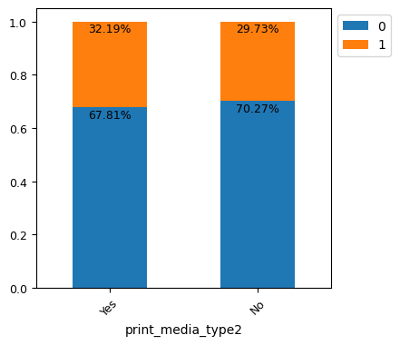

```python
stacked_barplot(data, "print_media_type2", "status")
```

**Observations:**

- The conversion rates are similar in both group (Yes/No).
- Combined with the fact that only 5% leads access magazine ad, it can conclude that magazine ad doesn't have clear effect on conversion rate.

#### Proportion of Conversions by Digital Media

| status digital_media | 0 | 1 | All | Conversion Rate |
| --- | --- | --- | --- | --- |
| All | 3235 | 1377 | 4612 | 29.86% |
| No | 2876 | 1209 | 4085 | 29.60% |
| Yes | 359 | 168 | 527 | 31.88% |

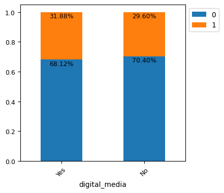

```python
stacked_barplot(data, "digital_media", "status")
```

**Observations:**

- Similar to above.

#### Proportion of Conversions by Educational Channels

| status educational_channels | 0 | 1 | All | Conversion Rate |
| --- | --- | --- | --- | --- |
| All | 3235 | 1377 | 4612 | 29.86% |
| No | 2727 | 1180 | 3907 | 30.20% |
| Yes | 508 | 197 | 705 | 27.94% |

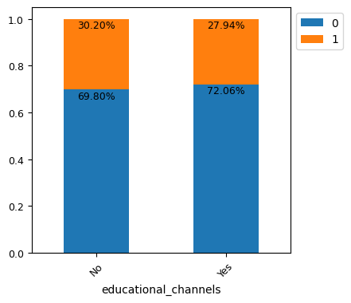

```python
stacked_barplot(data, "educational_channels", "status")
```

**Observations:**

- Similar to above.

#### Proportion of Conversions by Referral

**Observations:**

| status referral | 0 | 1 | All | Conversion Rate |
| --- | --- | --- | --- | --- |
| All | 3235 | 1377 | 4612 | 29.86% |
| No | 3205 | 1314 | 4519 | 29.08% |
| Yes | 30 | 63 | 93 | 67.74% |

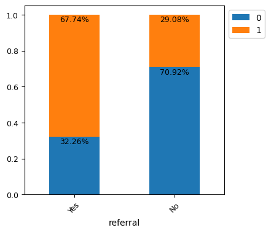

```python
stacked_barplot(data, "referral", "status")
```

**Observations:**

#### Data Preparation for modeling

- The most important business objective is to predict which lead is more likely to be converted.
- Categorical features should be encoded for modelling.
- Data will be split into training and testing.

```python
X = data.drop(["ID", "status"], axis=1) # independent variables
Y = data["status"] # dependent (target) variable
X = pd.get_dummies(X, drop_first=True) # dummies for X

# Splitting the data in 70:30 ratio for train to test data
X_train, X_test, y_train, y_test = train_test_split(
    X, Y, test_size=0.30, random_state=1
)
```

```python
print("Shape of Training set : ", X_train.shape)
print("Shape of test set : ", X_test.shape)
print("Percentage of classes in training set:")
print(y_train.value_counts(normalize=True))
print("Percentage of classes in test set:")
print(y_test.value_counts(normalize=True))
```

```
Shape of Training set :  (3228, 16)
Shape of test set :  (1384, 16)
Percentage of classes in training set:
status
0   0.70415
1   0.29585
Name: proportion, dtype: float64
Percentage of classes in test set:
status
0   0.69509
1   0.30491
Name: proportion, dtype: float64
```

## **Building Classification Models**

#### Model evaluation criterion

#### Model can make wrong predictions as:

1. Predicting a lead will not be converted to a paid customer in reality, but the lead would have converted to a paid customer.
2. Predicting a lead will be converted to a paid customer in reality, but the lead would not have converted to a paid customer.

#### Which case is more important?

- If we predict that a lead will not get converted and the lead would be converted. This is a critical scenario as it indicates the model's failure to recognize potential customers. The company might miss out on nurturing these leads effectively, resulting in lost revenue.
- If we predict that a lead will get converted and the lead doesn't get converted. This scenario represents a missed opportunity for resource allocation effectively since the company may invest time and effort to nurture these leads unnecessarily. It could also lead to wasted marketing resources.

Losing a potential customer is a greater loss.

#### How to reduce the losses?

- Company would want `Recall` to be maximized, the greater the Recall score higher are the chances of minimizing False Negatives.

```python
# Remark: this function is reutilized from Low Code Version - Potential Customers Prediction
# Function to print the classification report and get confusion matrix in a proper format
def metrics_score(actual, predicted):
    print(classification_report(actual, predicted))
    cm = confusion_matrix(actual, predicted)
    plt.figure(figsize = (8, 5))
    sns.heatmap(cm, annot = True,  fmt = '.2f', xticklabels = ['Not Converted', 'Converted'], yticklabels = ['Not Converted', 'Converted'])
    plt.ylabel('Actual')
    plt.xlabel('Predicted')
    plt.show()
```

## **Decision Tree**

### Building Decision Tree Model

```python
# Fitting the decision tree classifier on the training data
features = data.copy()
features = features.drop(["ID", "status"], axis=1)
d_tree = DecisionTreeClassifier(random_state=42)

d_tree.fit(X_train, y_train)
```

```
DecisionTreeClassifier(random_state=42)
```

#### Checking the Decision Tree performance on training set

```
              precision    recall  f1-score   support

           0       1.00      1.00      1.00      2273
           1       1.00      1.00      1.00       955

    accuracy                           1.00      3228
   macro avg       1.00      1.00      1.00      3228
weighted avg       1.00      1.00      1.00      3228
```

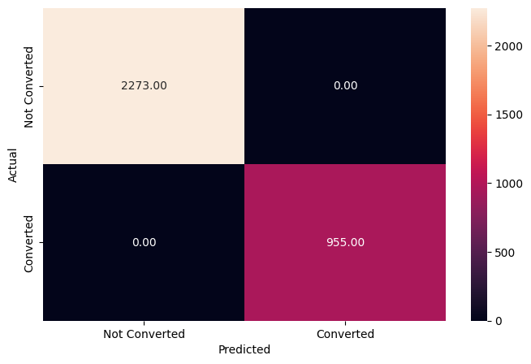

```python
# Checking performance on the training data
y_pred_train1 = d_tree.predict(X_train)
metrics_score(y_train, y_pred_train1)
```

**Observations:**

- The Decision tree is giving a **100% score for all metrics on the training dataset.**

#### Checking the Decision Tree performance on testing set

```
              precision    recall  f1-score   support

           0       0.87      0.86      0.86       962
           1       0.69      0.70      0.70       422

    accuracy                           0.81      1384
   macro avg       0.78      0.78      0.78      1384
weighted avg       0.81      0.81      0.81      1384
```

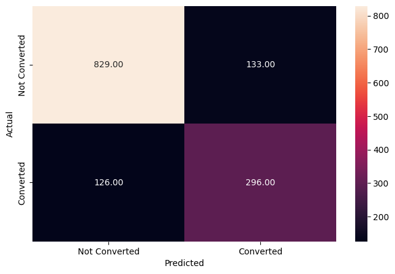

```python
# Checking performance on the testing data
y_pred_test1 = d_tree.predict(X_test)
metrics_score(y_test, y_pred_test1)
```

### **Observations:**

##### Overall Performance:

- The model achieves an overall accuracy of 81%
- Weighted average F1-score is 0.81, indicating good overall performance

##### Class Imbalance:

- The dataset is imbalanced with 962 non-converted leads (class 0) vs. 422 converted leads (class 1)
- This imbalance ratio of approximately 2.3:1 affects the model's performance on the minority class

##### Potential Improvements:

- Implementing class weights to address the imbalance could improve recall for the minority class
- Feature engineering or additional data might help better distinguish between the classes
- Hyperparameter tuning could potentially improve overall performance

The model shows decent predictive power but has room for improvement, particularly in correctly identifying potential conversions.

### **Decision Tree - Hyperparameter Tuning**

THe following bar plot is used to determine whether a class_weight hyperparameter should be used to build the decision tree.

#### Determine if the dataset has imbalance

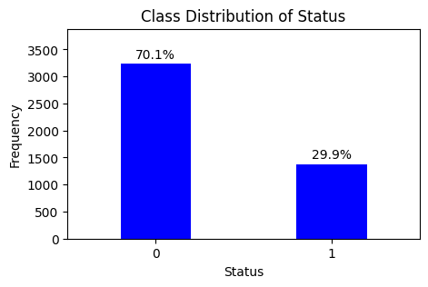

```python
# first determine whether a class weight is needed for a decision tree model
class_distribution = data['status'].value_counts()
total_count = class_distribution.sum()

# Calculate percentages
percentages = (class_distribution / total_count) * 100

# Plotting
plt.figure(figsize=(5, 3))
bars = plt.bar(class_distribution.index, class_distribution.values, color='blue', width=0.4)

# Adding percentage labels on top of the bars
for bar, percentage in zip(bars, percentages):
    yval = bar.get_height()
    #plt.text(bar.get_x() + bar.get_width()/2, yval, f'{percentage:.1f}%', ha='center', va='bottom')
    plt.text(bar.get_x() + bar.get_width()/2, yval + 50, f'{percentage:.1f}%', ha='center', va='bottom')  # Adjust yval and va

# Plot aesthetics
plt.title('Class Distribution of Status')
plt.xlabel('Status')
plt.ylabel('Frequency')
plt.xticks([0, 1])  # Set x-ticks to 0 and 1
plt.xlim(-0.5, 1.5)  # Set limits to center the bars properly

# Adjust y-axis limits to create space at the top
plt.ylim(0, class_distribution.max() * 1.2)  # Adjusted ylim factor

plt.show()
```

**Observations:**

- Percentage of status 0 significantly exceeds those with status 1, indicating an imbalance in the dataset.
- Since one of the business objectives is to identify potential converted leads, greater importance should be assigned to the minority class.
- A class weights (0: 0.3, 1: 0.7) will be used when building the decision tree.

#### The decision tree will be built with class weights and other parameters for avoiding overfitting.

```python
# Choose the type of classifier
d_tree_tuned = DecisionTreeClassifier(random_state = 42, class_weight = {0: 0.3, 1: 0.7})

# Grid of parameters to choose from
parameters = {'max_depth': np.arange(2, 10),
              'criterion': ['gini', 'entropy'],
              'min_samples_leaf': [5, 10, 20, 25]
             }

# Type of scoring used to compare parameter combinations - recall score for class 1
scorer = metrics.make_scorer(recall_score, pos_label = 1)

# Run the grid search
grid_obj = GridSearchCV(d_tree_tuned, parameters, scoring = scorer, cv = 5)
grid_obj = grid_obj.fit(X_train, y_train)

# Set the classifier to the best combination of parameters
d_tree_tuned = grid_obj.best_estimator_

# Fit the best algorithm to the data
d_tree_tuned.fit(X_train, y_train)
```

```
DecisionTreeClassifier(class_weight={0: 0.3, 1: 0.7}, criterion='entropy',
                       max_depth=np.int64(3), min_samples_leaf=5,
                       random_state=42)
```

#### Checking the Optisimized Decision Tree performance on training set

```
              precision    recall  f1-score   support

           0       0.94      0.77      0.85      2273
           1       0.62      0.88      0.73       955

    accuracy                           0.80      3228
   macro avg       0.78      0.83      0.79      3228
weighted avg       0.84      0.80      0.81      3228
```

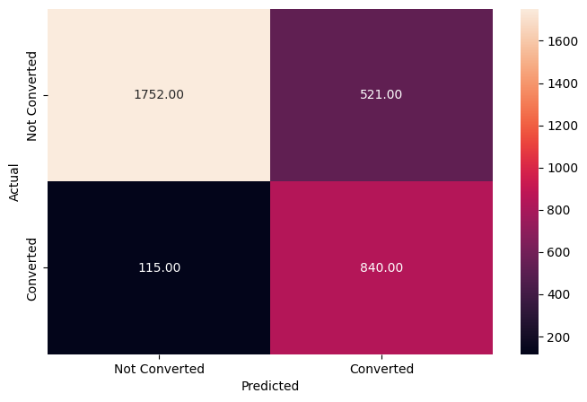

```python
# Checking performance on the training data
y_pred_train2 = d_tree_tuned.predict(X_train)  # Predictions on training set with tuned model
metrics_score(y_train, y_pred_train2)
```

#### Checking the Optisimized Decision Tree performance on testing set

```
              precision    recall  f1-score   support

           0       0.93      0.77      0.84       962
           1       0.62      0.86      0.72       422

    accuracy                           0.80      1384
   macro avg       0.77      0.82      0.78      1384
weighted avg       0.83      0.80      0.80      1384
```

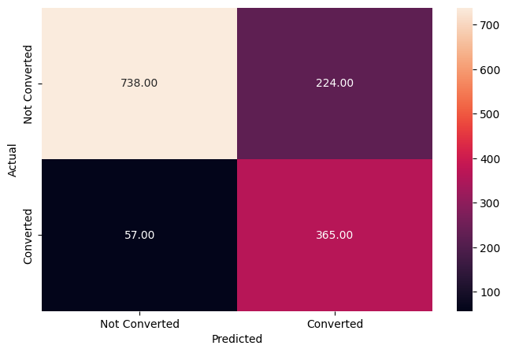

```python
# Checking performance on the testing data
y_pred_test2 = d_tree_tuned.predict(X_test)
metrics_score(y_test, y_pred_test2)  # Evaluate the tuned model's performance
```

**Observations:**

Based on testing data results, comparing the optimized decision tree with the untuned decision tree, here are the key observations:

##### 1. Recall for Converted Class (Class 1):

- Optimized: 0.86 (86%)
- Untuned: 0.70 (70%)
- Improvement: +16% - This is a significant improvement in identifying actual converters, which was the optimization goal - (using recall as the scoring metric)

##### 2. Precision Trade-off:

- Optimized: 0.62 for Class 1 (down from 0.69)
- Untuned: 0.69 for Class 1
- The model sacrificed some precision to achieve better recall

##### 3. Confusion Matrix Changes:

- False Negatives: Decreased from 126 to 57 (fewer missed conversion opportunities)
- False Positives: Increased from 133 to 224 (more non-converters incorrectly identified as converters)
- True Positives: Increased from 296 to 365 (more actual converters correctly identified)

##### 4. Overall Accuracy:

- Optimized: 0.80 (80%)
- Untuned: 0.81 (81%)
- Slight decrease in overall accuracy, but this is acceptable given the business goal

##### 5. Class Weights Impact:

- The class_weight={0: 0.3, 1: 0.7} parameter successfully shifted the model's focus toward better identifying the minority class (converters)
- This is evident in the improved recall for Class 1

##### 6. Business Implications:

- The optimized model would help the business identify 69 more potential customers (365 vs. 296)
- The cost is 91 more false positives (224 vs. 133), which means more resources spent on leads that won't convert
- This trade-off is often acceptable in lead conversion scenarios where missing potential customers is more costly than - spending resources on non-converters

##### 7. F1-Score:

- Class 1 F1-score improved slightly from 0.70 to 0.72, showing a better balance between precision and recall for the conversion class

The optimization was successful in achieving its primary goal of improving recall for the converted class, which is typically the more important business objective in lead conversion scenarios.

#### Visualizing the Decision Tree

[output not shown]

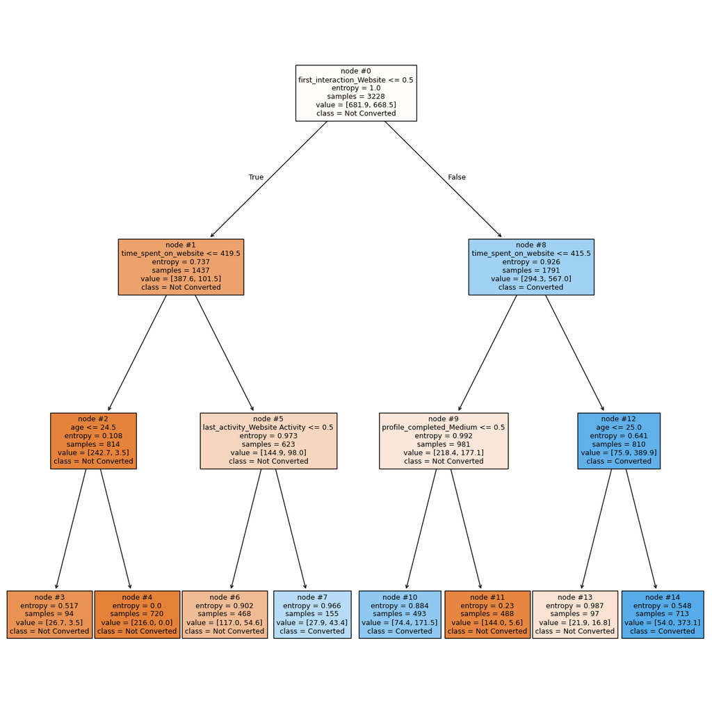

```
DecisionTreeClassifier(class_weight={0: 0.3, 1: 0.7}, criterion='entropy',
                       max_depth=np.int64(3), min_samples_leaf=5,
                       random_state=42)
```

```python
features = list(X.columns)
print(features)
plt.figure(figsize = (16, 16))

# convert means the leads converted to paid customers
class_names = ['Not Converted', 'Converted']
tree.plot_tree(d_tree_tuned, feature_names = features, filled = True, fontsize = 9, node_ids = True, class_names = class_names)
plt.show()
print(d_tree_tuned)
```

**Observations:**

##### **Ranking list of factors on leads conversion**:

1. First Interaction Method (Mobile vs Website):
   - This is the root node split, indicating it's the most determinating feature.
2. Time Spent on Website:
   - Appears immediately after the root split.
   - Longer sessions generally correlate with higher conversion probability.
3. Age:
   - Multiple splits based on age thresholds (24.5 and 25.0).
   - Shows that different age groups have distinct conversion patterns.
4. Profile Completion Status
   - Indicates user investment of time in ExtraaLearn platform.
   - Shows commitment level correlates with conversion likelihood.
5. Last Activity Type
   - indicates that the nature of lead's last interaction can predict conversion.

The above ranking list is based on entropy values, node depth and sample distribution.